# Spielplan - Deutsche Oper Berlin

[figure not shown]

[figure not shown]

[figure not shown]

[figure not shown]

[figure not shown]

[figure not shown]

[figure not shown]

[figure not shown]

[figure not shown]

[figure not shown]

[figure not shown]

[figure not shown]

[figure not shown]

Fünf Cellisten spielen Don Carlo

[figure not shown]

[figure not shown]

[figure not shown]

[figure not shown]

[figure not shown]

[figure not shown]

[figure not shown]

[figure not shown]

[figure not shown]

[figure not shown]

[figure not shown]

[figure not shown]

[figure not shown]

[figure not shown]

[figure not shown]

[figure not shown]

[figure not shown]

[figure not shown]

[figure not shown]

[figure not shown]

[figure not shown]

[figure not shown]

[figure not shown]

[figure not shown]

[figure not shown]

[figure not shown]

[figure not shown]

Giuseppe Verdi im Mai

# Don Carlo

Giuseppe Verdi (1813 – 1901)

[Karten für diese Produktion kaufen](https://tickets.deutscheoperberlin.de/webshop/webticket/shop?production=513&language=de)

Informationen zum Werk

Oper in vier Akten  
Libretto von Joseph Méry und Camille du Locle nach Friedrich Schillers Tragödie  
Uraufführung der italienischen Fassung von Achille de Lauzières am 10. Januar 1884 in Mailand  
Premiere an der Deutschen Oper Berlin am 23. Oktober 2011

3 Stunden 30 Minuten / Eine Pause

In italienischer Sprache mit deutschen und englischen Übertiteln

Einführung: 45 Minuten vor Vorstellungsbeginn im Rang-Foyer rechts

empfohlen ab 16 Jahren

Termine und Karten

- 08

  2025

  17:00

  Mai

  Do

  D-Preise: € 144,00 / 112,00 / 82,00 / 50,00 / 30,00
- 17

  2025

  19:00

  Mai

  Sa

  D-Preise: € 144,00 / 112,00 / 82,00 / 50,00 / 30,00
- 25

  2025

  17:00

  Mai

  So

  D-Preise: € 144,00 / 112,00 / 82,00 / 50,00 / 30,00

  [Karten kaufen](https://tickets.deutscheoperberlin.de/webshop/webticket/shop?event=11054&language=de)
- Zum letzten Mal in dieser Spielzeit

  29

  2025

  17:00

  Mai

  Do

  D-Preise: € 144,00 / 112,00 / 82,00 / 50,00 / 30,00

  [Karten kaufen](https://tickets.deutscheoperberlin.de/webshop/webticket/shop?event=11055&language=de)

Wir danken unseren Partnern

[figure not shown]

Mit Unterstützung des Förderkreises der Deutschen Oper Berlin e. V.

Zum Inhalt

**Zum Stück**  
Man weiß, dass Giuseppe Verdi sich als kritischer Geist nicht nur mit den Zeitläuften seiner Epoche herumgeplagt hat, sondern sehr wohl auch dem eigenen Schaffen mit stetig überarbeitungsbereiter Skepsis begegnet ist.  
Keine andere seiner Opern hat er so häufig redigiert, gekürzt, umgestellt und neugefasst wie ausgerechnet diejenige, die durch ihr engmaschiges Gewirk aus politischen, religiösen und gesellschaftlichen Zwängen am ehesten an die Unausweichlichkeiten des griechischen Dramas heranreicht und damit seine düsterste geworden ist: DON CARLO.  
Fast zwanzig Jahre liegen zwischen dem Kompositionsbeginn 1865 und der Mailänder Aufführung jener vieraktigen Fassung, die heute die meistgespielte ist. Verdi plagte sich dabei nicht nur mit den beiden Sprachen und ihren so verschiedenen Ausdrucksgestus, sondern versuchte auch immer wieder durch Kürzungen und Umstellungen zum optimalen Ergebnis zu gelangen. So bringt es die Schillers Drama in weiten Teilen getreue Oper auf nicht weniger als sieben Versionen.  
Das Licht der Vernunft freilich sieht man in keiner aufscheinen. Gefangene ihrer Zwänge, Gefangene in selbstangelegten Zügeln, Gefangene aber vor allen Dingen einer stets tödlich drohenden geistlichen Macht, der selbst die weltliche Herrschaft nicht gewachsen ist – die Ausweglosigkeit menschlicher Verstrickungen in diesem Netzwerk des Terrors bringt Verdi elementar auf den Punkt: Freiheit verspricht allenfalls der Tod.  
**Zur Inszenierung**  
Marco Arturo Marelli bringt Verdis epischen Opernklassiker bildgewaltig auf die Bühne. Dabei wird der Kampf um Freiheit und Unabhängigkeit unter der Herrschaft des absolutistischen Königs Philipps II. als zentrales Thema herausgearbeitet. Stets präsent verbirgt sich hinter allem die unerschütterliche Macht der Kirche, die in die Grundfesten dieser Gesellschaft eingemeißelt ist. In Verkörperung der Inquisition macht sie mit allem kurzen Prozess, das ihr gefährlich werden könnte, indem es die bestehenden Verhältnisse ins Wanken zu bringen versucht.

## Unsere Empfehlungen

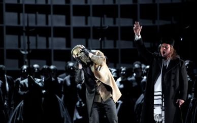

Nabucco

[mehr erfahren](https://deutscheoperberlin.de/de_DE/production/nabucco.1355940)

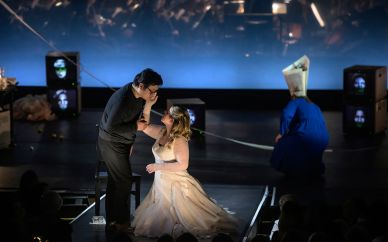

Aida

[mehr erfahren](https://deutscheoperberlin.de/de_DE/production/aida.1355605)

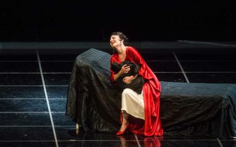

La traviata

[mehr erfahren](https://deutscheoperberlin.de/de_DE/production/la-traviata.1355576)

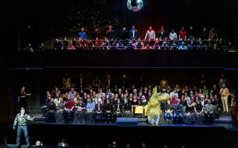

Rigoletto

[mehr erfahren](https://deutscheoperberlin.de/de_DE/production/rigoletto.1355819)

[figure not shown]

Les Vêpres Siciliennes

[mehr erfahren](https://deutscheoperberlin.de/de_DE/production/les-vepres-siciliennes.1355944)

[interactive chart not shown]